# Proyecto final: relevancia observable en una red de Twitter

Reporte técnico reproducible en R

Pablo Cambria (1136587)

Nataniel Félix (1135396)

Braian López (1137007)

05 de July de 2026

# 1 1. Objetivo y alcance

Este reporte analiza la red social conformada por cuentas de Twitter a partir del archivo `mensajes.csv`. El propósito es identificar los elementos más relevantes de la conversación y responder dos preguntas exploratorias:

1. **¿Qué hace relevante a un usuario dentro de la conversación observada?**
2. **¿Qué características se asocian con una mayor probabilidad de que un tweet alcance alta relevancia observable?**

La relevancia no se interpreta como una medida absoluta de importancia fuera de la plataforma. En este reporte se utiliza el concepto de **relevancia observable**, entendido como la combinación de alcance, respuesta de la audiencia, atención recibida e influencia estructural dentro de la red analizada.

# 2 Reproducibilidad y carga de datos

## 2.1 Paquetes requeridos

```r
paquetes_requeridos <- c(
  "readr", "dplyr", "tidyr", "stringr", "lubridate",
  "ggplot2", "igraph", "ggraph", "ggrepel", "knitr"
)

paquetes_faltantes <- paquetes_requeridos[
  !vapply(paquetes_requeridos, requireNamespace, logical(1), quietly = TRUE)
]

if (length(paquetes_faltantes) > 0) {
  stop(
    "Instale antes los paquetes faltantes: ",
    paste(paquetes_faltantes, collapse = ", ")
  )
}

library(readr)
library(dplyr)
library(tidyr)
library(stringr)
library(lubridate)
library(ggplot2)
library(igraph)
library(ggraph)
library(ggrepel)
```

## 2.2 Lectura de la base

```r
data_cruda <- read_csv(
  "mensajes.csv",
  locale = locale(encoding = "ISO-8859-1"),
  show_col_types = FALSE,
  name_repair = "minimal",
  progress = FALSE
)

columnas_requeridas <- c(
  "user_id", "status_id", "created_at", "screen_name", "text", "source",
  "display_text_width", "reply_to_status_id", "reply_to_user_id",
  "reply_to_screen_name", "is_quote", "is_retweet", "favorite_count",
  "retweet_count", "hashtags", "urls_expanded_url", "media_url", "media_type",
  "mentions_screen_name", "quoted_screen_name", "retweet_screen_name",
  "followers_count", "friends_count", "listed_count", "statuses_count",
  "account_created_at", "verified", "polarity"
)

columnas_faltantes <- setdiff(columnas_requeridas, names(data_cruda))

if (length(columnas_faltantes) > 0) {
  stop(
    "Faltan columnas requeridas en el CSV: ",
    paste(columnas_faltantes, collapse = ", ")
  )
}
```

# 3 Control de calidad y preparación

## 3.1 Funciones auxiliares

```r
limpiar_cadena <- function(x) {
  x <- str_squish(as.character(x))
  x[!is.na(x) & x == ""] <- NA_character_
  x
}

limpiar_handle <- function(x) {
  x <- limpiar_cadena(x)
  x <- str_remove(x, "^@")
  x <- str_replace_all(x, "\\s+", "")
  x <- str_to_lower(x)
  x[!is.na(x) & x == ""] <- NA_character_
  x
}

logico_seguro <- function(x) {
  if (is.logical(x)) {
    return(replace_na(x, FALSE))
  }

  x_limpio <- str_to_lower(str_squish(as.character(x)))
  salida <- rep(FALSE, length(x_limpio))
  salida[!is.na(x_limpio)] <- x_limpio[!is.na(x_limpio)] %in% c(
    "true", "t", "1", "yes", "si", "sí"
  )
  salida
}

moda <- function(x) {
  x <- x[!is.na(x) & x != ""]
  if (length(x) == 0) return(NA_character_)
  names(sort(table(x), decreasing = TRUE))[1]
}

primer_no_na <- function(x) {
  x <- x[!is.na(x) & x != ""]
  if (length(x) == 0) return(NA_character_)
  x[1]
}

min_seguro <- function(x) {
  x <- x[is.finite(x)]
  if (length(x) == 0) return(NA_real_)
  min(x)
}

max_seguro <- function(x) {
  x <- x[is.finite(x)]
  if (length(x) == 0) return(NA_real_)
  max(x)
}

media_segura <- function(x) {
  x <- x[is.finite(x)]
  if (length(x) == 0) return(NA_real_)
  mean(x)
}

sd_segura <- function(x) {
  x <- x[is.finite(x)]
  if (length(x) < 2) return(NA_real_)
  sd(x)
}

percentil_seguro <- function(x) {
  x <- replace_na(as.numeric(x), 0)
  if (length(unique(x)) < 2) return(rep(0, length(x)))
  percent_rank(x)
}

formato_numero <- function(x) {
  format(round(x, 0), big.mark = ",", scientific = FALSE, trim = TRUE)
}

formato_pct <- function(x, digitos = 1) {
  paste0(format(round(x * 100, digitos), nsmall = digitos), "%")
}

tema_reporte <- function() {
  theme_minimal(base_size = 12) +
    theme(
      plot.background = element_rect(fill = "#EDEDED", color = NA),
      panel.background = element_rect(fill = "#EDEDED", color = NA),
      panel.grid.major.y = element_blank(),
      panel.grid.minor = element_blank(),
      panel.grid.major.x = element_line(color = "white", linewidth = 0.35),
      plot.title = element_text(face = "bold", color = "#111827"),
      plot.subtitle = element_text(color = "#374151"),
      axis.text = element_text(color = "#111827"),
      axis.title = element_text(color = "#111827"),
      legend.background = element_rect(fill = "#EDEDED", color = NA),
      legend.key = element_rect(fill = "#EDEDED", color = NA)
    )
}
```

## 3.2 Resumen de calidad de datos

Los valores faltantes no se eliminan de manera global. En esta base, muchos valores ausentes representan que una característica no aplica: por ejemplo, un tweet original no tendrá una cuenta destino de respuesta, y un mensaje no citado no tendrá campos de cita.

```r
resumen_calidad <- tibble::tibble(
  variable = names(data_cruda),
  tipo_dato = vapply(data_cruda, function(x) class(x)[1], character(1)),
  valores_unicos = vapply(data_cruda, function(x) n_distinct(x, na.rm = TRUE), numeric(1)),
  cantidad_na = vapply(data_cruda, function(x) sum(is.na(x)), numeric(1)),
  cantidad_vacios = vapply(
    data_cruda,
    function(x) sum(!is.na(x) & trimws(as.character(x)) == ""),
    numeric(1)
  )
) |>
  mutate(
    total_faltantes = cantidad_na + cantidad_vacios,
    porcentaje_faltantes = round(total_faltantes / nrow(data_cruda) * 100, 2)
  ) |>
  arrange(desc(porcentaje_faltantes), desc(valores_unicos))

knitr::kable(
  head(resumen_calidad, 15),
  caption = "Variables con mayor proporción de valores faltantes"
)
```

Variables con mayor proporción de valores faltantes

| variable | tipo_dato | valores_unicos | cantidad_na | cantidad_vacios | total_faltantes | porcentaje_faltantes |
| --- | --- | --- | --- | --- | --- | --- |
| quote_count | logical | 0 | 5094 | 0 | 5094 | 100.00 |
| reply_count | logical | 0 | 5094 | 0 | 5094 | 100.00 |
| symbols | logical | 0 | 5094 | 0 | 5094 | 100.00 |
| ext_media_type | logical | 0 | 5094 | 0 | 5094 | 100.00 |
| account_lang | logical | 0 | 5094 | 0 | 5094 | 100.00 |
| quote_count.1 | logical | 0 | 5094 | 0 | 5094 | 100.00 |
| reply_count.1 | logical | 0 | 5094 | 0 | 5094 | 100.00 |
| place_url | character | 19 | 5036 | 0 | 5036 | 98.86 |
| place_name | character | 19 | 5036 | 0 | 5036 | 98.86 |
| place_full_name | character | 19 | 5036 | 0 | 5036 | 98.86 |
| place_type | character | 3 | 5036 | 0 | 5036 | 98.86 |
| country | character | 2 | 5036 | 0 | 5036 | 98.86 |
| country_code | character | 2 | 5036 | 0 | 5036 | 98.86 |
| quoted_location | character | 32 | 5017 | 0 | 5017 | 98.49 |
| quoted_description | character | 80 | 4955 | 0 | 4955 | 97.27 |

## 3.3 Construcción de una base mínima por mensaje

```r
base_tweets <- data_cruda |>
  transmute(
    id_tweet = as.character(status_id),
    usuario_id = as.character(user_id),
    screen_name = limpiar_handle(screen_name),
    texto = limpiar_cadena(text),
    fecha_tweet = ymd_hms(created_at, tz = "UTC", quiet = TRUE),
    fecha_creacion_cuenta = ymd_hms(account_created_at, tz = "UTC", quiet = TRUE),
    fuente = limpiar_cadena(source),
    ancho_texto = suppressWarnings(as.numeric(display_text_width)),
    es_cita = logico_seguro(is_quote),
    es_retweet = logico_seguro(is_retweet),
    reply_to_status_id = as.character(reply_to_status_id),
    reply_to_user_id = as.character(reply_to_user_id),
    reply_to_screen_name = limpiar_handle(reply_to_screen_name),
    retweet_screen_name = limpiar_handle(retweet_screen_name),
    quoted_screen_name = limpiar_handle(quoted_screen_name),
    mentions_screen_name = limpiar_cadena(mentions_screen_name),
    hashtags = limpiar_cadena(hashtags),
    tiene_url = !is.na(limpiar_cadena(urls_expanded_url)),
    tiene_media = !is.na(limpiar_cadena(media_url)),
    media_type = limpiar_cadena(media_type),
    polaridad = str_to_lower(limpiar_cadena(polarity)),
    favoritos = coalesce(suppressWarnings(as.numeric(favorite_count)), 0),
    retweets = coalesce(suppressWarnings(as.numeric(retweet_count)), 0),
    seguidores = coalesce(suppressWarnings(as.numeric(followers_count)), 0),
    seguidos = coalesce(suppressWarnings(as.numeric(friends_count)), 0),
    veces_en_listas = coalesce(suppressWarnings(as.numeric(listed_count)), 0),
    tweets_historicos = coalesce(suppressWarnings(as.numeric(statuses_count)), 0),
    cuenta_verificada = logico_seguro(verified)
  ) |>
  distinct(id_tweet, .keep_all = TRUE) |>
  mutate(
    es_respuesta = !is.na(reply_to_status_id) |
      !is.na(reply_to_user_id) |
      !is.na(reply_to_screen_name),
    tiene_hashtag = !is.na(hashtags),
    tiene_mencion = !is.na(mentions_screen_name),
    cantidad_hashtags = if_else(tiene_hashtag, str_count(hashtags, "\\S+"), 0L),
    cantidad_menciones = if_else(tiene_mencion, str_count(mentions_screen_name, "\\S+"), 0L),
    tipo_mensaje = case_when(
      es_retweet ~ "Retweet",
      es_cita ~ "Cita",
      es_respuesta ~ "Respuesta",
      TRUE ~ "Original"
    ),
    tipo_mensaje = factor(
      tipo_mensaje,
      levels = c("Retweet", "Respuesta", "Original", "Cita")
    )
  )

fecha_corte <- max(base_tweets$fecha_tweet, na.rm = TRUE)

base_tweets <- base_tweets |>
  mutate(
    antiguedad_cuenta_anios = as.numeric(
      difftime(fecha_corte, fecha_creacion_cuenta, units = "days")
    ) / 365.25,
    antiguedad_cuenta_anios = if_else(
      antiguedad_cuenta_anios >= 0,
      antiguedad_cuenta_anios,
      NA_real_
    )
  )

resumen_general <- tibble::tibble(
  indicador = c(
    "Mensajes analizados",
    "Status ID únicos",
    "Cuentas emisoras distintas",
    "Variables originales",
    "Inicio del período",
    "Fin del período"
  ),
  valor = c(
    formato_numero(nrow(base_tweets)),
    formato_numero(n_distinct(base_tweets$id_tweet)),
    formato_numero(n_distinct(base_tweets$usuario_id)),
    formato_numero(ncol(data_cruda)),
    format(min(base_tweets$fecha_tweet, na.rm = TRUE), "%d-%m-%Y"),
    format(max(base_tweets$fecha_tweet, na.rm = TRUE), "%d-%m-%Y")
  )
)

knitr::kable(resumen_general, caption = "Resumen general de la base analizada")
```

Resumen general de la base analizada

| indicador | valor |
| --- | --- |
| Mensajes analizados | 5,094 |
| Status ID únicos | 5,094 |
| Cuentas emisoras distintas | 1,900 |
| Variables originales | 93 |
| Inicio del período | 25-08-2022 |
| Fin del período | 29-08-2022 |

## 3.4 Exploración inicial de variables seleccionadas

La exploración inicial se concentró en las variables que aportan información para el análisis descriptivo, la construcción de la red y el modelo de relevancia. No se generaron gráficos individuales para identificadores, textos completos, URLs o nombres de usuario, debido a que presentan alta cardinalidad: la mayoría de sus valores son únicos y un gráfico de barras no ofrece una interpretación útil.

En cambio, se validó la unicidad de los identificadores, la presencia de los principales tipos de interacción, la disponibilidad de contenido adicional y la distribución de variables numéricas relevantes.

### 3.4.1 Validación de identificadores

```r
validacion_identificadores <- tibble(
  indicador = c(
    "Registros en el archivo original",
    "Status ID únicos",
    "Status ID duplicados",
    "Status ID faltantes o vacíos",
    "Cuentas emisoras únicas"
  ),
  valor = c(
    nrow(data_cruda),
    n_distinct(data_cruda$status_id),
    sum(duplicated(data_cruda$status_id)),
    sum(
      is.na(data_cruda$status_id) |
        trimws(as.character(data_cruda$status_id)) == ""
    ),
    n_distinct(base_tweets$usuario_id)
  )
) |>
  mutate(valor = formato_numero(valor))

knitr::kable(
  validacion_identificadores,
  caption = "Validación de identificadores de mensajes y cuentas"
)
```

Validación de identificadores de mensajes y cuentas

| indicador | valor |
| --- | --- |
| Registros en el archivo original | 5,094 |
| Status ID únicos | 5,094 |
| Status ID duplicados | 0 |
| Status ID faltantes o vacíos | 0 |
| Cuentas emisoras únicas | 1,900 |

El identificador `status_id` se utilizó como clave del mensaje. La validación permite confirmar si cada publicación corresponde a un registro único dentro de la base analizada.

### 3.4.2 Presencia de interacciones y elementos de contenido

```r
resumen_elementos <- tibble(
  elemento = c(
    "Mensajes clasificados como retweet",
    "Mensajes clasificados como respuesta",
    "Mensajes clasificados como cita",
    "Mensajes con al menos una mención",
    "Mensajes con al menos un hashtag",
    "Mensajes con URL",
    "Mensajes con contenido multimedia"
  ),
  cantidad = c(
    sum(base_tweets$es_retweet, na.rm = TRUE),
    sum(base_tweets$es_respuesta, na.rm = TRUE),
    sum(base_tweets$es_cita, na.rm = TRUE),
    sum(base_tweets$tiene_mencion, na.rm = TRUE),
    sum(base_tweets$tiene_hashtag, na.rm = TRUE),
    sum(base_tweets$tiene_url, na.rm = TRUE),
    sum(base_tweets$tiene_media, na.rm = TRUE)
  )
) |>
  mutate(
    porcentaje = cantidad / nrow(base_tweets),
    porcentaje = formato_pct(porcentaje)
  )

knitr::kable(
  resumen_elementos,
  caption = "Presencia de interacciones y elementos de contenido en los mensajes"
)
```

Presencia de interacciones y elementos de contenido en los mensajes

| elemento | cantidad | porcentaje |
| --- | --- | --- |
| Mensajes clasificados como retweet | 3443 | 67.6% |
| Mensajes clasificados como respuesta | 909 | 17.8% |
| Mensajes clasificados como cita | 149 | 2.9% |
| Mensajes con al menos una mención | 4571 | 89.7% |
| Mensajes con al menos un hashtag | 636 | 12.5% |
| Mensajes con URL | 493 | 9.7% |
| Mensajes con contenido multimedia | 549 | 10.8% |

Esta revisión permitió identificar qué elementos estaban suficientemente representados para incorporarlos al análisis. Las variables de respuesta, retweet, cita, mención y contenido multimedia se trataron como atributos estructurales: su ausencia significa, en muchos casos, que la característica no aplica al mensaje.

### 3.4.3 Resumen de variables numéricas relevantes

```r
resumen_numerico <- tibble(
  variable = c(
    "Ancho visible del texto",
    "Favoritos recibidos",
    "Retweets recibidos",
    "Seguidores del autor",
    "Cuentas seguidas por el autor"
  ),
  minimo = c(
    min_seguro(base_tweets$ancho_texto),
    min_seguro(base_tweets$favoritos),
    min_seguro(base_tweets$retweets),
    min_seguro(base_tweets$seguidores),
    min_seguro(base_tweets$seguidos)
  ),
  mediana = c(
    median(base_tweets$ancho_texto, na.rm = TRUE),
    median(base_tweets$favoritos, na.rm = TRUE),
    median(base_tweets$retweets, na.rm = TRUE),
    median(base_tweets$seguidores, na.rm = TRUE),
    median(base_tweets$seguidos, na.rm = TRUE)
  ),
  promedio = c(
    media_segura(base_tweets$ancho_texto),
    media_segura(base_tweets$favoritos),
    media_segura(base_tweets$retweets),
    media_segura(base_tweets$seguidores),
    media_segura(base_tweets$seguidos)
  ),
  percentil_95 = c(
    quantile(base_tweets$ancho_texto, 0.95, na.rm = TRUE),
    quantile(base_tweets$favoritos, 0.95, na.rm = TRUE),
    quantile(base_tweets$retweets, 0.95, na.rm = TRUE),
    quantile(base_tweets$seguidores, 0.95, na.rm = TRUE),
    quantile(base_tweets$seguidos, 0.95, na.rm = TRUE)
  ),
  maximo = c(
    max_seguro(base_tweets$ancho_texto),
    max_seguro(base_tweets$favoritos),
    max_seguro(base_tweets$retweets),
    max_seguro(base_tweets$seguidores),
    max_seguro(base_tweets$seguidos)
  )
) |>
  mutate(
    across(
      c(minimo, mediana, promedio, percentil_95, maximo),
      ~ formato_numero(.x)
    )
  )

knitr::kable(
  resumen_numerico,
  caption = "Resumen de variables numéricas seleccionadas"
)
```

Resumen de variables numéricas seleccionadas

| variable | minimo | mediana | promedio | percentil_95 | maximo |
| --- | --- | --- | --- | --- | --- |
| Ancho visible del texto | 10 | 140 | 148 | 273 | 280 |
| Favoritos recibidos | 0 | 0 | 2 | 7 | 700 |
| Retweets recibidos | 0 | 8 | 17 | 69 | 209 |
| Seguidores del autor | 0 | 246 | 9,999 | 7,330 | 1,603,513 |
| Cuentas seguidas por el autor | 0 | 412 | 1,192 | 5,001 | 44,876 |

### 3.4.4 Distribución de engagement

Las variables de favoritos y retweets suelen presentar una distribución asimétrica: muchos mensajes reciben pocas interacciones y un grupo reducido concentra valores altos. Por esta razón, se utiliza la transformación `log(1 + x)` para visualizar la distribución sin que los valores extremos oculten el comportamiento general.

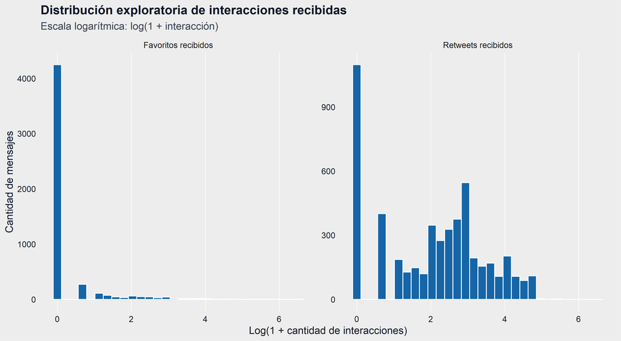

```r
engagement_exploratorio <- base_tweets |>
  select(favoritos, retweets) |>
  pivot_longer(
    cols = everything(),
    names_to = "variable",
    values_to = "valor"
  ) |>
  mutate(
    variable = recode(
      variable,
      favoritos = "Favoritos recibidos",
      retweets = "Retweets recibidos"
    ),
    valor_log = log1p(valor)
  )

ggplot(
  engagement_exploratorio,
  aes(x = valor_log)
) +
  geom_histogram(
    bins = 30,
    fill = "#1565A7",
    color = "white"
  ) +
  facet_wrap(
    ~ variable,
    scales = "free_y"
  ) +
  labs(
    title = "Distribución exploratoria de interacciones recibidas",
    subtitle = "Escala logarítmica: log(1 + interacción)",
    x = "Log(1 + cantidad de interacciones)",
    y = "Cantidad de mensajes"
  ) +
  tema_reporte()
```

### 3.4.5 Polaridad de los mensajes

```r
resumen_polaridad <- base_tweets |>
  filter(!is.na(polaridad)) |>
  count(polaridad, name = "cantidad") |>
  mutate(
    porcentaje = cantidad / sum(cantidad),
    porcentaje = formato_pct(porcentaje)
  ) |>
  arrange(desc(cantidad))

knitr::kable(
  resumen_polaridad,
  caption = "Distribución de polaridad de los mensajes"
)
```

Distribución de polaridad de los mensajes

| polaridad | cantidad | porcentaje |
| --- | --- | --- |
| neutral | 3231 | 63.4% |
| positive | 1404 | 27.6% |
| negative | 459 | 9.0% |

La exploración permitió seleccionar variables con suficiente información y sentido analítico para las etapas posteriores. En particular, las métricas de interacción, atributos de la cuenta, tipo de mensaje, polaridad, menciones, URLs y contenido multimedia fueron consideradas en la construcción de los datasets analíticos y en el modelo logístico.

# 4 Análisis descriptivo

## 4.1 Tipos de mensaje

```r
resumen_tipos <- base_tweets |>
  count(tipo_mensaje, name = "cantidad") |>
  mutate(
    porcentaje = cantidad / sum(cantidad),
    destacado = if_else(tipo_mensaje == "Retweet", "Retweet", "Otros")
  )

knitr::kable(
  resumen_tipos |>
    mutate(porcentaje = formato_pct(porcentaje)) |>
    select(tipo_mensaje, cantidad, porcentaje),
  caption = "Distribución de mensajes por tipo"
)
```

Distribución de mensajes por tipo

| tipo_mensaje | cantidad | porcentaje |
| --- | --- | --- |
| Retweet | 3443 | 67.6% |
| Respuesta | 893 | 17.5% |
| Original | 609 | 12.0% |
| Cita | 149 | 2.9% |

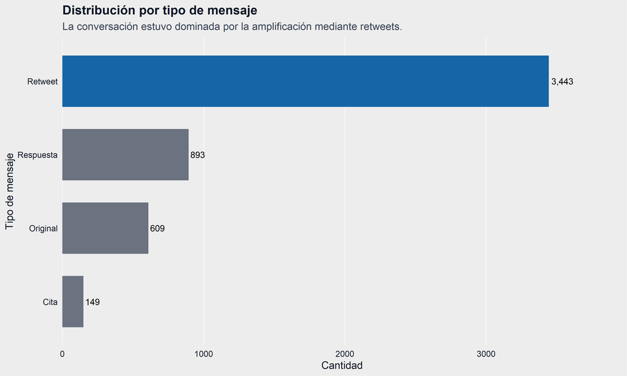

```r
ggplot(resumen_tipos, aes(x = reorder(tipo_mensaje, cantidad), y = cantidad, fill = destacado)) +
  geom_col(width = 0.7) +
  geom_text(aes(label = formato_numero(cantidad)), hjust = -0.12, size = 3.6) +
  coord_flip() +
  scale_fill_manual(values = c("Retweet" = "#1565A7", "Otros" = "#6B7280"), guide = "none") +
  scale_y_continuous(expand = expansion(mult = c(0, 0.15))) +
  labs(
    title = "Distribución por tipo de mensaje",
    subtitle = "La conversación estuvo dominada por la amplificación mediante retweets.",
    x = "Tipo de mensaje",
    y = "Cantidad"
  ) +
  tema_reporte()
```

## 4.2 Fuentes de publicación

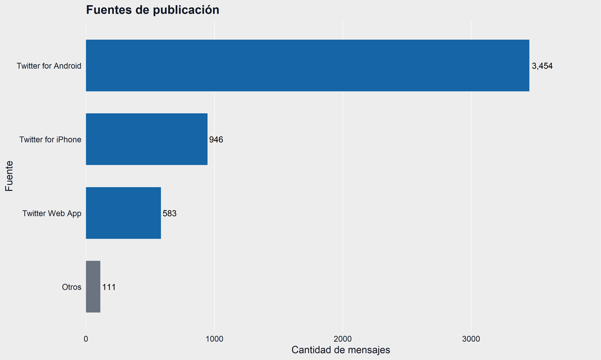

```r
fuentes_resumen <- base_tweets |>
  filter(!is.na(fuente)) |>
  mutate(
    fuente_agrupada = case_when(
      fuente %in% c("Twitter for Android", "Twitter for iPhone", "Twitter Web App") ~ fuente,
      TRUE ~ "Otros"
    )
  ) |>
  count(fuente_agrupada, name = "cantidad") |>
  mutate(
    fuente_agrupada = factor(
      fuente_agrupada,
      levels = c("Otros", "Twitter Web App", "Twitter for iPhone", "Twitter for Android")
    )
  )

ggplot(fuentes_resumen, aes(x = fuente_agrupada, y = cantidad, fill = fuente_agrupada)) +
  geom_col(width = 0.7) +
  geom_text(aes(label = formato_numero(cantidad)), hjust = -0.12, size = 3.6) +
  coord_flip() +
  scale_fill_manual(
    values = c(
      "Twitter for Android" = "#1565A7",
      "Twitter for iPhone" = "#1565A7",
      "Twitter Web App" = "#1565A7",
      "Otros" = "#6B7280"
    ),
    guide = "none"
  ) +
  scale_y_continuous(expand = expansion(mult = c(0, 0.15))) +
  labs(
    title = "Fuentes de publicación",
    x = "Fuente",
    y = "Cantidad de mensajes"
  ) +
  tema_reporte()
```

# 5 Dataset por usuario

Cada fila del siguiente dataset representa una cuenta emisora. La tabla reúne actividad, características de perfil, engagement recibido y métricas de red.

```r
actividad_usuarios <- base_tweets |>
  filter(!is.na(usuario_id), !is.na(screen_name)) |>
  group_by(usuario_id) |>
  summarise(
    screen_name = moda(screen_name),
    fuente_mas_usada = moda(fuente),
    cantidad_total_mensajes = n(),
    tweets_originales = sum(tipo_mensaje == "Original"),
    respuestas_emitidas = sum(tipo_mensaje == "Respuesta"),
    citas_emitidas = sum(tipo_mensaje == "Cita"),
    retweets_emitidos = sum(tipo_mensaje == "Retweet"),
    publicaciones_no_retweet = sum(tipo_mensaje != "Retweet"),
    ancho_texto_minimo = min_seguro(ancho_texto),
    ancho_texto_maximo = max_seguro(ancho_texto),
    ancho_texto_promedio = media_segura(ancho_texto),
    ancho_texto_desviacion = sd_segura(ancho_texto),
    hashtags_emitidos = sum(cantidad_hashtags, na.rm = TRUE),
    menciones_emitidas = sum(cantidad_menciones, na.rm = TRUE),
    mensajes_con_url = sum(tiene_url, na.rm = TRUE),
    mensajes_con_multimedia = sum(tiene_media, na.rm = TRUE),
    likes_recibidos = sum(if_else(tipo_mensaje != "Retweet", favoritos, 0), na.rm = TRUE),
    retweets_recibidos = sum(if_else(tipo_mensaje != "Retweet", retweets, 0), na.rm = TRUE),
    engagement_recibido = sum(
      if_else(tipo_mensaje != "Retweet", favoritos + retweets, 0),
      na.rm = TRUE
    ),
    .groups = "drop"
  )

perfil_usuarios <- base_tweets |>
  filter(!is.na(usuario_id)) |>
  arrange(usuario_id, fecha_tweet) |>
  group_by(usuario_id) |>
  slice_tail(n = 1) |>
  transmute(
    usuario_id,
    fecha_creacion_cuenta,
    antiguedad_cuenta_anios,
    seguidores_observados = seguidores,
    seguidos_observados = seguidos,
    veces_en_listas,
    tweets_historicos,
    cuenta_verificada
  ) |>
  ungroup()
```

# 6 Red consolidada de interacciones

La red se construye con cuatro tipos de aristas dirigidas: **menciones, respuestas, retweets y citas**. En todas las aristas, el origen es la cuenta que ejecuta la acción y el destino es la cuenta que la recibe.

## 6.1 Construcción de aristas

```r
diccionario_usuarios <- base_tweets |>
  filter(!is.na(usuario_id), !is.na(screen_name)) |>
  group_by(usuario_id) |>
  summarise(destino_por_id = primer_no_na(screen_name), .groups = "drop")

aristas_menciones <- base_tweets |>
  filter(!is.na(screen_name), !is.na(mentions_screen_name)) |>
  transmute(
    id_tweet,
    origen = screen_name,
    destino = mentions_screen_name,
    tipo_interaccion = "Mención"
  ) |>
  separate_rows(destino, sep = "\\s+") |>
  mutate(destino = limpiar_handle(destino)) |>
  filter(!is.na(origen), !is.na(destino), origen != destino) |>
  distinct(id_tweet, origen, destino, tipo_interaccion)

aristas_respuestas <- base_tweets |>
  filter(es_respuesta, !is.na(screen_name)) |>
  select(id_tweet, origen = screen_name, reply_to_user_id, reply_to_screen_name) |>
  left_join(diccionario_usuarios, by = c("reply_to_user_id" = "usuario_id")) |>
  transmute(
    id_tweet,
    origen,
    destino = coalesce(reply_to_screen_name, destino_por_id),
    tipo_interaccion = "Respuesta"
  ) |>
  filter(!is.na(origen), !is.na(destino), origen != destino) |>
  distinct(id_tweet, origen, destino, tipo_interaccion)

aristas_retweets <- base_tweets |>
  filter(es_retweet, !is.na(screen_name), !is.na(retweet_screen_name)) |>
  transmute(
    id_tweet,
    origen = screen_name,
    destino = retweet_screen_name,
    tipo_interaccion = "Retweet"
  ) |>
  filter(origen != destino) |>
  distinct(id_tweet, origen, destino, tipo_interaccion)

aristas_citas <- base_tweets |>
  filter(es_cita, !is.na(screen_name), !is.na(quoted_screen_name)) |>
  transmute(
    id_tweet,
    origen = screen_name,
    destino = quoted_screen_name,
    tipo_interaccion = "Cita"
  ) |>
  filter(origen != destino) |>
  distinct(id_tweet, origen, destino, tipo_interaccion)

aristas_red <- bind_rows(
  aristas_menciones,
  aristas_respuestas,
  aristas_retweets,
  aristas_citas
)

resumen_interacciones <- aristas_red |>
  count(tipo_interaccion, name = "cantidad") |>
  mutate(porcentaje = cantidad / sum(cantidad)) |>
  arrange(desc(cantidad))

knitr::kable(
  resumen_interacciones |>
    mutate(porcentaje = formato_pct(porcentaje)) |>
    select(tipo_interaccion, cantidad, porcentaje),
  caption = "Interacciones incluidas en la red consolidada"
)
```

Interacciones incluidas en la red consolidada

| tipo_interaccion | cantidad | porcentaje |
| --- | --- | --- |
| Mención | 11269 | 72.1% |
| Retweet | 3322 | 21.3% |
| Respuesta | 881 | 5.6% |
| Cita | 149 | 1.0% |

## 6.2 Métricas de red

```r
aristas_ponderadas <- aristas_red |>
  count(origen, destino, name = "peso") |>
  mutate(distancia = 1 / peso)

if (nrow(aristas_ponderadas) == 0) {
  stop("No se generaron aristas válidas para construir la red.")
}

red_twitter <- graph_from_data_frame(aristas_ponderadas, directed = TRUE)

pagerank_red <- page_rank(
  red_twitter,
  directed = TRUE,
  weights = E(red_twitter)$peso
)$vector

metricas_red <- tibble::tibble(
  screen_name = names(pagerank_red),
  grado_entrada = as.numeric(degree(red_twitter, mode = "in")),
  grado_salida = as.numeric(degree(red_twitter, mode = "out")),
  interacciones_recibidas = as.numeric(
    strength(red_twitter, mode = "in", weights = E(red_twitter)$peso)
  ),
  pagerank = as.numeric(pagerank_red),
  betweenness = as.numeric(
    betweenness(
      red_twitter,
      directed = TRUE,
      weights = E(red_twitter)$distancia,
      normalized = TRUE
    )
  )
)

menciones_recibidas <- aristas_red |>
  filter(tipo_interaccion == "Mención") |>
  count(destino, name = "menciones_recibidas") |>
  rename(screen_name = destino)

comentarios_recibidos <- aristas_red |>
  filter(tipo_interaccion == "Respuesta") |>
  count(destino, name = "comentarios_recibidos") |>
  rename(screen_name = destino)

retweets_recibidos_red <- aristas_red |>
  filter(tipo_interaccion == "Retweet") |>
  count(destino, name = "retweets_recibidos_red") |>
  rename(screen_name = destino)

citas_recibidas <- aristas_red |>
  filter(tipo_interaccion == "Cita") |>
  count(destino, name = "citas_recibidas") |>
  rename(screen_name = destino)

componentes <- components(as.undirected(red_twitter, mode = "collapse"))

resumen_red <- tibble::tibble(
  indicador = c(
    "Nodos en la red",
    "Aristas únicas ponderadas",
    "Interacciones crudas",
    "Componente débil principal",
    "Proporción en el componente principal"
  ),
  valor = c(
    formato_numero(vcount(red_twitter)),
    formato_numero(ecount(red_twitter)),
    formato_numero(nrow(aristas_red)),
    formato_numero(max(componentes$csize)),
    formato_pct(max(componentes$csize) / vcount(red_twitter))
  )
)

knitr::kable(resumen_red, caption = "Resumen de la red consolidada")
```

Resumen de la red consolidada

| indicador | valor |
| --- | --- |
| Nodos en la red | 2,352 |
| Aristas únicas ponderadas | 6,310 |
| Interacciones crudas | 15,621 |
| Componente débil principal | 2,228 |
| Proporción en el componente principal | 94.7% |

### 6.2.1 Interpretación de métricas

| Métrica | Pregunta que responde | Lectura dentro de este proyecto |
| --- | --- | --- |
| Grado de entrada | ¿Cuántas cuentas distintas interactúan con una cuenta? | Visibilidad o atención recibida. |
| Grado de salida | ¿Con cuántas cuentas distintas interactúa una cuenta? | Actividad relacional. |
| PageRank | ¿Qué tan importante es una cuenta según quiénes se conectan con ella? | Influencia estructural. |
| Betweenness | ¿Qué tanto conecta una cuenta comunidades diferentes? | Rol de puente o intermediación. |

## 6.3 Visualización de la red

Para facilitar la lectura, el gráfico muestra la subred inducida por las 150 cuentas con PageRank más alto. Las métricas, no obstante, se calcularon sobre la red consolidada completa.

[figure not shown]

```r
vertices_red <- metricas_red |>
  mutate(
    es_top = if_else(
      pagerank >= quantile(pagerank, 0.98, na.rm = TRUE),
      "Top 2% PageRank",
      "Resto"
    ),
    ranking_pagerank = rank(-pagerank, ties.method = "first"),
    etiqueta = if_else(ranking_pagerank <= 15, screen_name, NA_character_)
  ) |>
  rename(name = screen_name)

red_visual <- graph_from_data_frame(
  aristas_ponderadas,
  vertices = vertices_red,
  directed = TRUE
)

nodos_visualizacion <- vertices_red |>
  slice_min(ranking_pagerank, n = min(150, nrow(vertices_red)), with_ties = FALSE) |>
  pull(name)

subred_visual <- induced_subgraph(
  red_visual,
  vids = V(red_visual)[name %in% nodos_visualizacion]
)

ggraph(subred_visual, layout = "fr") +
  geom_edge_link(
    aes(width = peso, alpha = peso),
    color = "#4B5563",
    show.legend = TRUE
  ) +
  scale_edge_width(range = c(0.25, 1.8), name = "Frecuencia") +
  scale_edge_alpha(range = c(0.12, 0.75), guide = "none") +
  geom_node_point(
    aes(fill = es_top, size = pagerank),
    shape = 21,
    color = "#374151",
    stroke = 0.55,
    alpha = 1
  ) +
  scale_fill_manual(
    values = c("Top 2% PageRank" = "#1565A7", "Resto" = "#FFFFFF"),
    name = "Nivel de influencia"
  ) +
  scale_size_continuous(range = c(2.5, 10), name = "PageRank") +
  geom_node_label(
    aes(label = etiqueta),
    repel = TRUE,
    size = 3,
    fontface = "bold",
    color = "black",
    fill = "white",
    alpha = 0.92,
    label.size = 0.2,
    label.r = grid::unit(0.08, "lines"),
    box.padding = 0.35,
    point.padding = 0.5,
    segment.color = "#6B7280"
  ) +
  labs(
    title = "Red consolidada de interacciones entre cuentas",
    subtitle = "Tamaño: PageRank | Azul: top 2% por PageRank | Se muestran las 150 cuentas más centrales"
  ) +
  theme_void() +
  theme(
    plot.background = element_rect(fill = "#EDEDED", color = NA),
    panel.background = element_rect(fill = "#EDEDED", color = NA),
    legend.background = element_rect(fill = "#EDEDED", color = NA),
    legend.key = element_rect(fill = "#EDEDED", color = NA),
    plot.title = element_text(hjust = 0.5, face = "bold", color = "#111827"),
    plot.subtitle = element_text(hjust = 0.5, color = "#374151")
  )
```

# 7 Índice exploratorio de relevancia observable

El índice integra seis componentes. Antes de ponderarlos, cada componente se transforma en un percentil para que sus escalas sean comparables.

| Componente | Peso | Qué representa |
| --- | --- | --- |
| Seguidores observados | 20% | Alcance potencial. |
| Engagement recibido | 25% | Respuesta recibida por publicaciones propias no-retweet. |
| Menciones recibidas | 15% | Atención directa dentro de la conversación. |
| Grado de entrada | 15% | Cantidad de cuentas distintas que interactúan con la cuenta. |
| PageRank | 15% | Influencia estructural dentro de la red. |
| Betweenness | 10% | Capacidad de conectar comunidades. |

```r
dataset_usuarios <- actividad_usuarios |>
  left_join(perfil_usuarios, by = "usuario_id") |>
  left_join(menciones_recibidas, by = "screen_name") |>
  left_join(comentarios_recibidos, by = "screen_name") |>
  left_join(retweets_recibidos_red, by = "screen_name") |>
  left_join(citas_recibidas, by = "screen_name") |>
  left_join(metricas_red, by = "screen_name") |>
  mutate(
    across(
      c(
        menciones_recibidas, comentarios_recibidos, retweets_recibidos_red,
        citas_recibidas, grado_entrada, grado_salida, interacciones_recibidas,
        pagerank, betweenness
      ),
      ~ replace_na(.x, 0)
    ),
    p_seguidores = percentil_seguro(log1p(seguidores_observados)),
    p_engagement = percentil_seguro(log1p(engagement_recibido)),
    p_menciones = percentil_seguro(log1p(menciones_recibidas)),
    p_grado_entrada = percentil_seguro(log1p(grado_entrada)),
    p_pagerank = percentil_seguro(pagerank),
    p_betweenness = percentil_seguro(betweenness),
    puntaje_relevancia = round(
      100 * (
        0.20 * p_seguidores +
          0.25 * p_engagement +
          0.15 * p_menciones +
          0.15 * p_grado_entrada +
          0.15 * p_pagerank +
          0.10 * p_betweenness
      ),
      2
    )
  )

umbral_usuario_relevante <- quantile(
  dataset_usuarios$puntaje_relevancia,
  probs = 0.80,
  na.rm = TRUE
)

dataset_usuarios <- dataset_usuarios |>
  mutate(
    usuario_relevante = if_else(
      puntaje_relevancia >= umbral_usuario_relevante,
      1L,
      0L
    )
  )

validacion_usuarios <- tibble::tibble(
  indicador = c("Filas del dataset por usuario", "Cuentas emisoras únicas en la base"),
  valor = c(nrow(dataset_usuarios), n_distinct(base_tweets$usuario_id))
)

knitr::kable(validacion_usuarios, caption = "Validación del dataset agregado por usuario")
```

Validación del dataset agregado por usuario

| indicador | valor |
| --- | --- |
| Filas del dataset por usuario | 1900 |
| Cuentas emisoras únicas en la base | 1900 |

## 7.1 Perfil de las cuentas

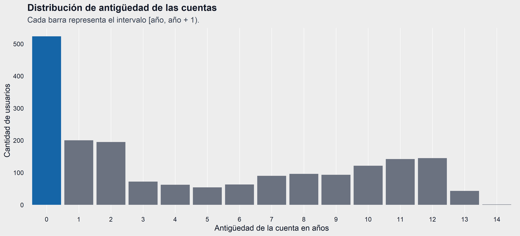

```r
antiguedad_plot <- dataset_usuarios |>
  filter(!is.na(antiguedad_cuenta_anios), is.finite(antiguedad_cuenta_anios)) |>
  mutate(intervalo_anios = floor(antiguedad_cuenta_anios)) |>
  count(intervalo_anios, name = "cantidad") |>
  mutate(destacado = if_else(cantidad == max(cantidad), "Intervalo modal", "Otros"))

ggplot(antiguedad_plot, aes(x = factor(intervalo_anios), y = cantidad, fill = destacado)) +
  geom_col(width = 0.9) +
  scale_fill_manual(values = c("Intervalo modal" = "#1565A7", "Otros" = "#6B7280"), guide = "none") +
  labs(
    title = "Distribución de antigüedad de las cuentas",
    subtitle = "Cada barra representa el intervalo [año, año + 1).",
    x = "Antigüedad de la cuenta en años",
    y = "Cantidad de usuarios"
  ) +
  tema_reporte()
```

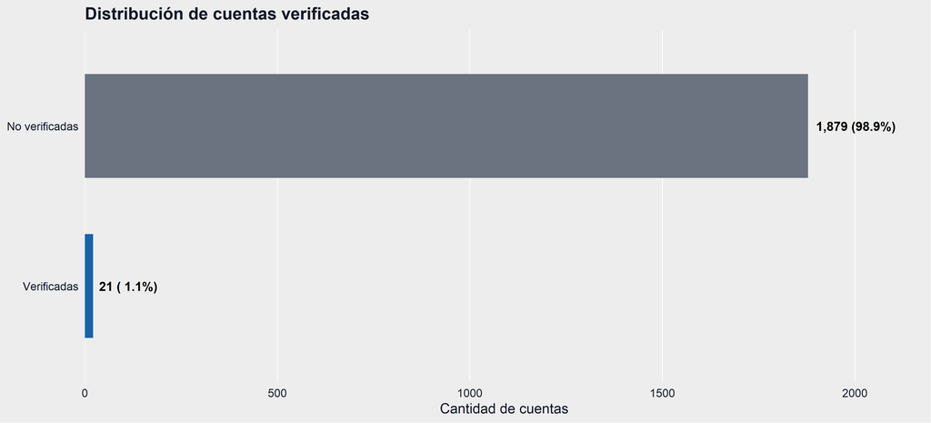

```r
verificados_plot <- dataset_usuarios |>
  count(cuenta_verificada, name = "cantidad") |>
  mutate(
    estado = if_else(cuenta_verificada, "Verificadas", "No verificadas"),
    porcentaje = cantidad / sum(cantidad),
    etiqueta = paste0(formato_numero(cantidad), " (", formato_pct(porcentaje), ")"),
    estado = factor(estado, levels = c("Verificadas", "No verificadas"))
  )

ggplot(verificados_plot, aes(x = reorder(estado, cantidad), y = cantidad, fill = estado)) +
  geom_col(width = 0.65) +
  geom_text(aes(label = etiqueta), hjust = -0.1, fontface = "bold", size = 3.8) +
  coord_flip() +
  scale_fill_manual(values = c("Verificadas" = "#1565A7", "No verificadas" = "#6B7280"), guide = "none") +
  scale_y_continuous(expand = expansion(mult = c(0, 0.16))) +
  labs(
    title = "Distribución de cuentas verificadas",
    x = NULL,
    y = "Cantidad de cuentas"
  ) +
  tema_reporte()
```

## 7.2 Por qué los rankings aislados no bastan

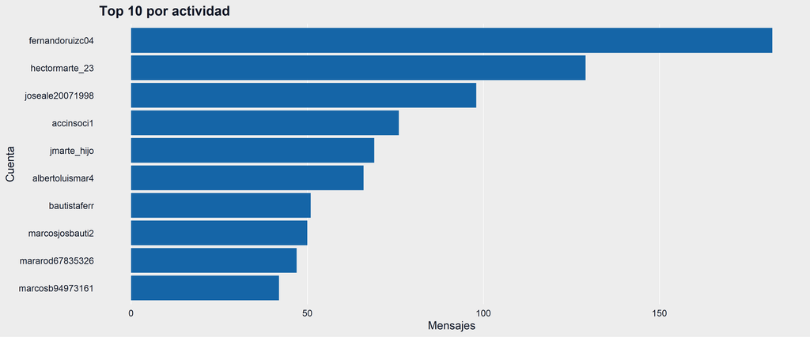

```r
top_mensajes <- dataset_usuarios |>
  slice_max(cantidad_total_mensajes, n = 10, with_ties = FALSE) |>
  mutate(screen_name = reorder(screen_name, cantidad_total_mensajes))

top_seguidores <- dataset_usuarios |>
  slice_max(seguidores_observados, n = 10, with_ties = FALSE) |>
  mutate(screen_name = reorder(screen_name, seguidores_observados))

top_engagement <- dataset_usuarios |>
  slice_max(engagement_recibido, n = 10, with_ties = FALSE) |>
  mutate(screen_name = reorder(screen_name, engagement_recibido))

ggplot(top_mensajes, aes(x = screen_name, y = cantidad_total_mensajes)) +
  geom_col(fill = "#1565A7") +
  coord_flip() +
  labs(title = "Top 10 por actividad", x = "Cuenta", y = "Mensajes") +
  tema_reporte()
```

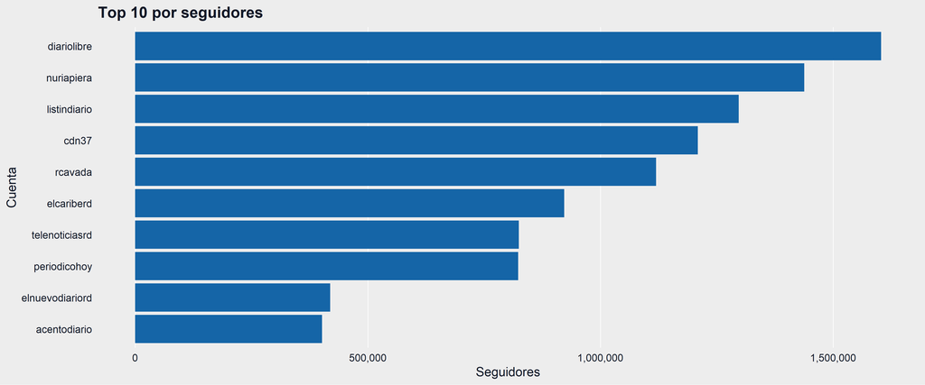

```r
ggplot(top_seguidores, aes(x = screen_name, y = seguidores_observados)) +
  geom_col(fill = "#1565A7") +
  coord_flip() +
  scale_y_continuous(labels = formato_numero) +
  labs(title = "Top 10 por seguidores", x = "Cuenta", y = "Seguidores") +
  tema_reporte()
```

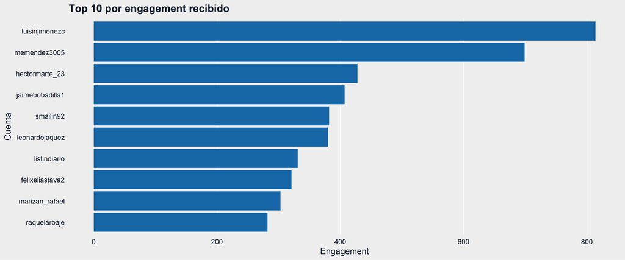

```r
ggplot(top_engagement, aes(x = screen_name, y = engagement_recibido)) +
  geom_col(fill = "#1565A7") +
  coord_flip() +
  scale_y_continuous(labels = formato_numero) +
  labs(title = "Top 10 por engagement recibido", x = "Cuenta", y = "Engagement") +
  tema_reporte()
```

Los rankings anteriores responden preguntas distintas: actividad, alcance potencial y reacción recibida. Por ello, ninguno de ellos por sí solo describe completamente la relevancia dentro de la red.

## 7.3 Resultados del índice

```r
top_relevantes <- dataset_usuarios |>
  slice_max(puntaje_relevancia, n = 15, with_ties = FALSE) |>
  mutate(screen_name = reorder(screen_name, puntaje_relevancia))

knitr::kable(
  top_relevantes |>
    transmute(
      cuenta = screen_name,
      puntaje = puntaje_relevancia,
      seguidores = formato_numero(seguidores_observados),
      engagement = formato_numero(engagement_recibido),
      grado_entrada,
      pagerank = round(pagerank, 4),
      betweenness = round(betweenness, 4)
    ),
  caption = "Top 15 de usuarios por índice exploratorio de relevancia"
)
```

Top 15 de usuarios por índice exploratorio de relevancia

| cuenta | puntaje | seguidores | engagement | grado_entrada | pagerank | betweenness |
| --- | --- | --- | --- | --- | --- | --- |
| marizan_rafael | 98.72 | 7,994 | 303 | 62 | 0.0105 | 0.0059 |
| comunicaciondo | 98.45 | 95,061 | 277 | 47 | 0.0045 | 0.0000 |
| raquelarbaje | 98.45 | 309,663 | 282 | 96 | 0.0067 | 0.0000 |
| bautarojas | 98.14 | 44,026 | 131 | 32 | 0.0028 | 0.0001 |
| jaimebobadilla1 | 98.14 | 4,024 | 407 | 82 | 0.0107 | 0.0033 |
| hectormarte_23 | 98.00 | 3,511 | 428 | 96 | 0.0063 | 0.0135 |
| smailin92 | 97.59 | 6,186 | 382 | 56 | 0.0069 | 0.0000 |
| felixeliastava2 | 97.45 | 2,855 | 321 | 62 | 0.0122 | 0.0008 |
| eddydegracia | 97.32 | 22,061 | 16 | 45 | 0.0049 | 0.0011 |
| joeltorresdo | 97.19 | 20,583 | 41 | 38 | 0.0011 | 0.0000 |
| grecoherasme | 97.09 | 6,913 | 53 | 38 | 0.0035 | 0.0001 |
| guzmanfermin1 | 96.72 | 14,864 | 21 | 18 | 0.0022 | 0.0013 |
| leofana2 | 96.65 | 7,174 | 72 | 21 | 0.0025 | 0.0000 |
| samy_cho | 96.64 | 28,152 | 23 | 11 | 0.0024 | 0.0020 |
| puebloexigerd | 96.44 | 14,585 | 69 | 21 | 0.0023 | 0.0000 |

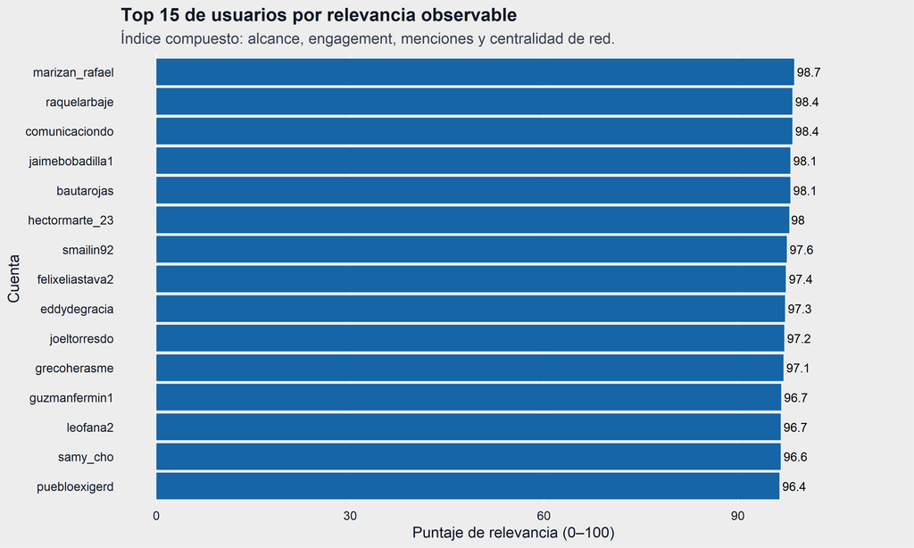

```r
ggplot(top_relevantes, aes(x = screen_name, y = puntaje_relevancia)) +
  geom_col(fill = "#1565A7") +
  coord_flip() +
  geom_text(aes(label = round(puntaje_relevancia, 1)), hjust = -0.12, size = 3.4) +
  scale_y_continuous(limits = c(0, max(top_relevantes$puntaje_relevancia) * 1.12)) +
  labs(
    title = "Top 15 de usuarios por relevancia observable",
    subtitle = "Índice compuesto: alcance, engagement, menciones y centralidad de red.",
    x = "Cuenta",
    y = "Puntaje de relevancia (0–100)"
  ) +
  tema_reporte()
```

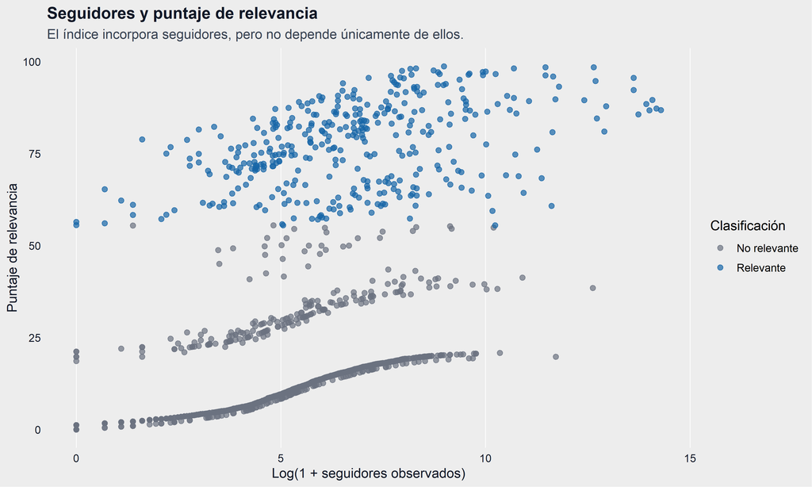

```r
ggplot(
  dataset_usuarios,
  aes(
    x = log1p(seguidores_observados),
    y = puntaje_relevancia,
    color = factor(usuario_relevante)
  )
) +
  geom_point(alpha = 0.7, size = 2) +
  scale_color_manual(
    values = c("0" = "#6B7280", "1" = "#1565A7"),
    labels = c("No relevante", "Relevante"),
    name = "Clasificación"
  ) +
  labs(
    title = "Seguidores y puntaje de relevancia",
    subtitle = "El índice incorpora seguidores, pero no depende únicamente de ellos.",
    x = "Log(1 + seguidores observados)",
    y = "Puntaje de relevancia"
  ) +
  tema_reporte()
```

# 8 Dataset por tweet y modelo logístico

Para modelar la relevancia de un tweet se excluyen los retweets. Esta decisión evita atribuir a la cuenta que comparte un contenido la popularidad del tweet original.

La variable objetivo se define así:

$$\text{Engagement} = \text{favoritos} + \text{retweets}$$

Un tweet es considerado relevante si su engagement se encuentra en el percentil 80 o superior de los tweets no-retweet.

```r
dataset_tweets_modelo <- base_tweets |>
  filter(!es_retweet) |>
  transmute(
    id_tweet,
    usuario_id,
    screen_name,
    texto,
    fecha_tweet,
    hora_publicacion = hour(fecha_tweet),
    dia_semana = wday(fecha_tweet, label = TRUE, week_start = 1),
    antiguedad_cuenta_anios,
    seguidores_autor = seguidores,
    cuenta_verificada,
    fuente = coalesce(fuente, "Sin dato"),
    tipo_mensaje = factor(tipo_mensaje, levels = c("Cita", "Original", "Respuesta")),
    ancho_texto,
    tiene_hashtag,
    cantidad_hashtags,
    tiene_mencion,
    cantidad_menciones,
    tiene_url,
    tiene_media,
    media_type = coalesce(media_type, "Sin multimedia"),
    polaridad,
    likes = favoritos,
    retweets = retweets,
    engagement = favoritos + retweets
  )

umbral_relevancia_tweet <- quantile(
  dataset_tweets_modelo$engagement,
  probs = 0.80,
  na.rm = TRUE
)

dataset_tweets_modelo <- dataset_tweets_modelo |>
  mutate(
    tweet_relevante = if_else(engagement >= umbral_relevancia_tweet, 1L, 0L)
  )

resumen_modelo_tweets <- dataset_tweets_modelo |>
  count(tweet_relevante, name = "cantidad") |>
  mutate(
    clasificacion = if_else(tweet_relevante == 1, "Relevante", "No relevante"),
    porcentaje = cantidad / sum(cantidad)
  ) |>
  select(clasificacion, cantidad, porcentaje)

knitr::kable(
  resumen_modelo_tweets |>
    mutate(porcentaje = formato_pct(porcentaje)),
  caption = paste0(
    "Clasificación de tweets no-retweet; umbral de engagement: ",
    formato_numero(umbral_relevancia_tweet)
  )
)
```

Clasificación de tweets no-retweet; umbral de engagement: 7

| clasificacion | cantidad | porcentaje |
| --- | --- | --- |
| No relevante | 1308 | 79.2% |
| Relevante | 343 | 20.8% |

## 8.1 Preparación y especificación del modelo

El modelo no utiliza `likes`, `retweets` ni `engagement` como variables predictoras, porque dichas variables ya se utilizan para construir la etiqueta `tweet_relevante`. Incluirlas como predictores produciría fuga de información.

```r
modelo_tweets <- dataset_tweets_modelo |>
  mutate(
    log_seguidores = log1p(seguidores_autor),
    fuente_modelo = case_when(
      fuente %in% c("Twitter for Android", "Twitter for iPhone", "Twitter Web App") ~ fuente,
      TRUE ~ "Otra"
    ),
    cuenta_verificada = factor(as.character(cuenta_verificada), levels = c("FALSE", "TRUE")),
    tipo_mensaje = factor(tipo_mensaje, levels = c("Cita", "Original", "Respuesta")),
    polaridad = factor(polaridad, levels = c("negative", "neutral", "positive")),
    fuente_modelo = factor(
      fuente_modelo,
      levels = c("Otra", "Twitter for Android", "Twitter for iPhone", "Twitter Web App")
    ),
    tiene_url = factor(as.character(tiene_url), levels = c("FALSE", "TRUE")),
    tiene_media = factor(as.character(tiene_media), levels = c("FALSE", "TRUE"))
  ) |>
  filter(
    !is.na(tweet_relevante),
    !is.na(ancho_texto),
    !is.na(antiguedad_cuenta_anios),
    !is.na(polaridad),
    !is.na(tipo_mensaje)
  )

modelo_logistico_completo <- glm(
  tweet_relevante ~
    log_seguidores +
    cuenta_verificada +
    antiguedad_cuenta_anios +
    tipo_mensaje +
    ancho_texto +
    cantidad_hashtags +
    cantidad_menciones +
    tiene_url +
    tiene_media +
    polaridad +
    hora_publicacion +
    fuente_modelo,
  family = binomial(link = "logit"),
  data = modelo_tweets
)

# Modelo parsimonioso: conserva los predictores con sustento analítico y evidencia
# en el modelo exploratorio completo. La comparación se documenta más abajo.
modelo_logistico_final <- glm(
  tweet_relevante ~
    log_seguidores +
    cuenta_verificada +
    antiguedad_cuenta_anios +
    tipo_mensaje +
    cantidad_menciones +
    tiene_url +
    polaridad,
  family = binomial(link = "logit"),
  data = modelo_tweets
)

comparacion_modelos <- AIC(
  modelo_logistico_completo,
  modelo_logistico_final
)

knitr::kable(
  comparacion_modelos,
  caption = "Comparación por AIC entre el modelo completo y el modelo parsimonioso"
)
```

Comparación por AIC entre el modelo completo y el modelo parsimonioso

|  | df | AIC |
| --- | --- | --- |
| modelo_logistico_completo | 17 | 1324.476 |
| modelo_logistico_final | 10 | 1323.443 |

```r
coeficientes_completos <- summary(modelo_logistico_completo)$coefficients

variables_sin_evidencia <- tibble::tibble(
  termino = rownames(coeficientes_completos),
  estimado = coeficientes_completos[, "Estimate"],
  p_valor = coeficientes_completos[, "Pr(>|z|)"]
) |>
  filter(
    termino %in% c(
      "ancho_texto", "cantidad_hashtags", "tiene_mediaTRUE", "hora_publicacion"
    )
  ) |>
  mutate(
    variable = recode(
      termino,
      ancho_texto = "Longitud del tweet",
      cantidad_hashtags = "Cantidad de hashtags",
      tiene_mediaTRUE = "Incluye multimedia",
      hora_publicacion = "Hora de publicación"
    ),
    `p-valor` = signif(p_valor, 3)
  ) |>
  select(variable, `p-valor`)

knitr::kable(
  variables_sin_evidencia,
  caption = "Variables sin evidencia individual de asociación clara en el modelo completo"
)
```

Variables sin evidencia individual de asociación clara en el modelo completo

| variable | p-valor |
| --- | --- |
| Longitud del tweet | 0.513 |
| Cantidad de hashtags | 0.684 |
| Incluye multimedia | 0.857 |
| Hora de publicación | 0.991 |

## 8.2 Odds ratios e intervalos de confianza

```r
coeficientes_modelo <- summary(modelo_logistico_final)$coefficients
intervalos_modelo <- confint.default(modelo_logistico_final)

tabla_or <- tibble::tibble(
  termino = rownames(coeficientes_modelo),
  estimado = coeficientes_modelo[, "Estimate"],
  p_valor = coeficientes_modelo[, "Pr(>|z|)"],
  or = exp(estimado),
  ic_inferior = exp(intervalos_modelo[, 1]),
  ic_superior = exp(intervalos_modelo[, 2])
) |>
  filter(termino != "(Intercept)") |>
  mutate(
    variable = case_when(
      termino == "log_seguidores" ~ "Log(1 + seguidores)",
      termino == "cuenta_verificadaTRUE" ~ "Cuenta verificada (vs. no verificada)",
      termino == "antiguedad_cuenta_anios" ~ "Antigüedad de la cuenta (por año)",
      termino == "tipo_mensajeOriginal" ~ "Tweet original (vs. cita)",
      termino == "tipo_mensajeRespuesta" ~ "Respuesta (vs. cita)",
      termino == "cantidad_menciones" ~ "Cantidad de menciones",
      termino == "tiene_urlTRUE" ~ "Incluye URL (vs. sin URL)",
      termino == "polaridadneutral" ~ "Polaridad neutral (vs. negativa)",
      termino == "polaridadpositive" ~ "Polaridad positiva (vs. negativa)",
      TRUE ~ termino
    )
  )

knitr::kable(
  tabla_or |>
    transmute(
      variable,
      `Odds ratio` = round(or, 3),
      `IC 95% inferior` = round(ic_inferior, 3),
      `IC 95% superior` = round(ic_superior, 3),
      `p-valor` = signif(p_valor, 3)
    ),
  caption = "Odds ratios del modelo logístico parsimonioso"
)
```

Odds ratios del modelo logístico parsimonioso

| variable | Odds ratio | IC 95% inferior | IC 95% superior | p-valor |
| --- | --- | --- | --- | --- |
| Log(1 + seguidores) | 1.396 | 1.291 | 1.508 | 0.00e+00 |
| Cuenta verificada (vs. no verificada) | 5.690 | 2.481 | 13.052 | 4.05e-05 |
| Antigüedad de la cuenta (por año) | 0.883 | 0.848 | 0.919 | 0.00e+00 |
| Tweet original (vs. cita) | 0.075 | 0.041 | 0.139 | 0.00e+00 |
| Respuesta (vs. cita) | 0.014 | 0.007 | 0.029 | 0.00e+00 |
| Cantidad de menciones | 1.252 | 1.190 | 1.317 | 0.00e+00 |
| Incluye URL (vs. sin URL) | 0.105 | 0.060 | 0.186 | 0.00e+00 |
| Polaridad neutral (vs. negativa) | 1.651 | 0.979 | 2.785 | 6.01e-02 |
| Polaridad positiva (vs. negativa) | 1.987 | 1.141 | 3.461 | 1.53e-02 |

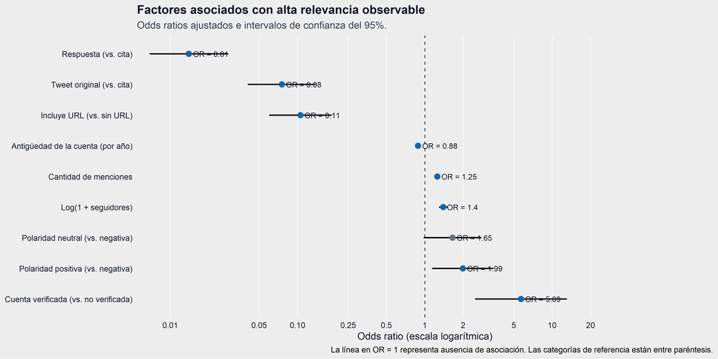

```r
tabla_or_grafico <- tabla_or |>
  mutate(
    variable = factor(variable, levels = rev(variable[order(or)])),
    significativo = if_else(p_valor < 0.05, "Significativo", "No significativo")
  )

ggplot(tabla_or_grafico, aes(x = or, y = variable)) +
  geom_vline(xintercept = 1, linetype = "dashed", color = "#374151") +
  geom_segment(aes(x = ic_inferior, xend = ic_superior, yend = variable), linewidth = 0.8) +
  geom_point(aes(color = significativo), size = 3) +
  geom_text(
    aes(label = paste0("OR = ", round(or, 2))),
    hjust = -0.12,
    size = 3.2,
    color = "#111827"
  ) +
  scale_color_manual(values = c("Significativo" = "#1565A7", "No significativo" = "#6B7280"), guide = "none") +
  scale_x_log10(
    breaks = c(0.01, 0.05, 0.10, 0.25, 0.5, 1, 2, 5, 10, 20),
    labels = c("0.01", "0.05", "0.10", "0.25", "0.5", "1", "2", "5", "10", "20"),
    expand = expansion(mult = c(0.03, 0.35))
  ) +
  labs(
    title = "Factores asociados con alta relevancia observable",
    subtitle = "Odds ratios ajustados e intervalos de confianza del 95%.",
    x = "Odds ratio (escala logarítmica)",
    y = NULL,
    caption = "La línea en OR = 1 representa ausencia de asociación. Las categorías de referencia están entre paréntesis."
  ) +
  tema_reporte()
```

## 8.3 Ajuste y lectura del modelo

```r
r2_mcfadden <- 1 - (
  modelo_logistico_final$deviance / modelo_logistico_final$null.deviance
)

resumen_ajuste <- tibble::tibble(
  indicador = c(
    "Observaciones utilizadas",
    "AIC del modelo final",
    "Pseudo R² de McFadden",
    "Umbral de relevancia"
  ),
  valor = c(
    nobs(modelo_logistico_final),
    round(AIC(modelo_logistico_final), 2),
    round(r2_mcfadden, 3),
    umbral_relevancia_tweet
  )
)

knitr::kable(resumen_ajuste, caption = "Indicadores de ajuste del modelo logístico")
```

Indicadores de ajuste del modelo logístico

| indicador | valor |
| --- | --- |
| Observaciones utilizadas | 1651.000 |
| AIC del modelo final | 1323.440 |
| Pseudo R² de McFadden | 0.227 |
| Umbral de relevancia | 7.000 |

```r
# Prueba de eliminación por término del modelo completo. Es preferible a interpretar
# exclusivamente el anova secuencial, ya que evalúa el aporte de cada término manteniendo los demás.
drop1(modelo_logistico_completo, test = "Chisq")
```

```
## Single term deletions
##
## Model:
## tweet_relevante ~ log_seguidores + cuenta_verificada + antiguedad_cuenta_anios +
##     tipo_mensaje + ancho_texto + cantidad_hashtags + cantidad_menciones +
##     tiene_url + tiene_media + polaridad + hora_publicacion +
##     fuente_modelo
##                         Df Deviance    AIC     LRT  Pr(>Chi)
## <none>                       1290.5 1324.5
## log_seguidores           1   1366.9 1398.9  76.429 < 2.2e-16 ***
## cuenta_verificada        1   1309.7 1341.7  19.263 1.139e-05 ***
## antiguedad_cuenta_anios  1   1322.3 1354.3  31.870 1.649e-08 ***
## tipo_mensaje             2   1434.7 1464.7 144.217 < 2.2e-16 ***
## ancho_texto              1   1290.9 1322.9   0.429  0.512633
## cantidad_hashtags        1   1290.6 1322.6   0.163  0.686066
## cantidad_menciones       1   1367.9 1399.9  77.434 < 2.2e-16 ***
## tiene_url                1   1342.0 1374.0  51.493 7.185e-13 ***
## tiene_media              1   1290.5 1322.5   0.032  0.857333
## polaridad                2   1296.9 1326.9   6.403  0.040707 *
## hora_publicacion         1   1290.5 1322.5   0.000  0.991044
## fuente_modelo            3   1303.0 1331.0  12.509  0.005829 **
## ---
## Signif. codes:  0 '***' 0.001 '**' 0.01 '*' 0.05 '.' 0.1 ' ' 1
```

# 9 Conclusiones y limitaciones

## 9.1 Conclusiones

- La conversación analizada estuvo dominada por los retweets, lo que evidencia una dinámica de amplificación de contenido existente.
- Los rankings simples por actividad, seguidores o engagement no son equivalentes: cada uno mide una dimensión distinta de la presencia de una cuenta.
- El **índice exploratorio de relevancia observable** permite combinar alcance potencial, respuesta de la audiencia, atención directa y centralidad dentro de la red.
- En el modelo logístico, las asociaciones deben leerse como relaciones observadas en esta muestra; no prueban causalidad.
- Los resultados del modelo permiten evaluar cómo se relacionan el alcance, la verificación de cuenta, el tipo de publicación, las menciones, las URL y la polaridad con la probabilidad de que un tweet alcance alto engagement.

## 9.2 Limitaciones

1. La base cubre un período corto y una conversación específica; no representa la totalidad de Twitter/X ni el comportamiento histórico completo de cada cuenta.
2. La relevancia del usuario se define con un índice exploratorio cuyos pesos fueron establecidos como una decisión analítica del grupo.
3. La relevancia del tweet se aproxima mediante engagement observable; no equivale necesariamente a impacto social, político o informativo.
4. Las métricas de centralidad dependen de las interacciones disponibles en la muestra.
5. El modelo logístico identifica asociaciones ajustadas, no relaciones causales. Factores externos no observados —tema coyuntural, algoritmo de la plataforma y exposición previa— también pueden afectar el engagement.
6. El archivo presenta caracteres con codificación inconsistente en algunos textos. Esto no afecta de manera material la construcción de la red, ya que esta se basa en identificadores y handles estructurados; sin embargo, limita análisis semánticos profundos del texto.

## 9.3 Declaración de uso de inteligencia artificial

Para el desarrollo de este proyecto se utilizó ChatGPT (GPT-5.5 Thinking) como herramienta de apoyo en la organización del código en R, la identificación y corrección de errores, la estructuración del análisis, la mejora de comentarios técnicos y la redacción de explicaciones metodológicas.

La inteligencia artificial no sustituyó el trabajo analítico del grupo. Los integrantes revisaron, ajustaron y validaron el código utilizado, verificaron los resultados obtenidos en R y asumieron la responsabilidad por las decisiones metodológicas, la interpretación de las métricas de red, la construcción del índice exploratorio de relevancia observable y las conclusiones presentadas.

En particular, las decisiones sobre la selección de variables, la definición de relevancia, las ponderaciones del índice, la construcción de la red de interacciones y la interpretación del modelo de regresión logística fueron revisadas y aprobadas por los integrantes del equipo.